# Lab 04: data visualisation exercises

The eight optional Star Wars exercises

2026-10-23

These exercises use `dplyr::starwars`. The project kick-off work is in investigation.html, which explores a candidate dataset for the group to discuss.

## Exercise 1: inspect the data

```r
glimpse(starwars_df)
```

```
## Rows: 87
## Columns: 14
## $ name       <chr> "Luke Skywalker", "C-3PO", "R2-D2", "Darth Vader", "Leia Or~
## $ height     <int> 172, 167, 96, 202, 150, 178, 165, 97, 183, 182, 188, 180, 2~
## $ mass       <dbl> 77.0, 75.0, 32.0, 136.0, 49.0, 120.0, 75.0, 32.0, 84.0, 77.~
## $ hair_color <chr> "blond", NA, NA, "none", "brown", "brown, grey", "brown", N~
## $ skin_color <chr> "fair", "gold", "white, blue", "white", "light", "light", "~
## $ eye_color  <chr> "blue", "yellow", "red", "yellow", "brown", "blue", "blue",~
## $ birth_year <dbl> 19.0, 112.0, 33.0, 41.9, 19.0, 52.0, 47.0, NA, 24.0, 57.0, ~
## $ sex        <chr> "male", "none", "none", "male", "female", "male", "female",~
## $ gender     <chr> "masculine", "masculine", "masculine", "masculine", "femini~
## $ homeworld  <chr> "Tatooine", "Tatooine", "Naboo", "Tatooine", "Alderaan", "T~
## $ species    <chr> "Human", "Droid", "Droid", "Human", "Human", "Human", "Huma~
## $ films      <list> <"A New Hope", "The Empire Strikes Back", "Return of the J~
## $ vehicles   <list> <"Snowspeeder", "Imperial Speeder Bike">, <>, <>, <>, "Imp~
## $ starships  <list> <"X-wing", "Imperial shuttle">, <>, <>, "TIE Advanced x1",~
```

```r
starwars_df %>%
  summarise(across(c(height, mass, birth_year, sex, gender),
                   ~ sum(is.na(.x))))
```

```
## # A tibble: 1 x 5
##   height  mass birth_year   sex gender
##    <int> <int>      <int> <int>  <int>
## 1      6    28         44     4      4
```

There are 87 characters and 14 columns. `height` and `mass` are numerical variables. `sex`, `gender` and `species` are categorical variables stored as text. `films`, `vehicles` and `starships` are list columns, so one character can have several entries in each of them.

## Exercise 2: make all the points pink

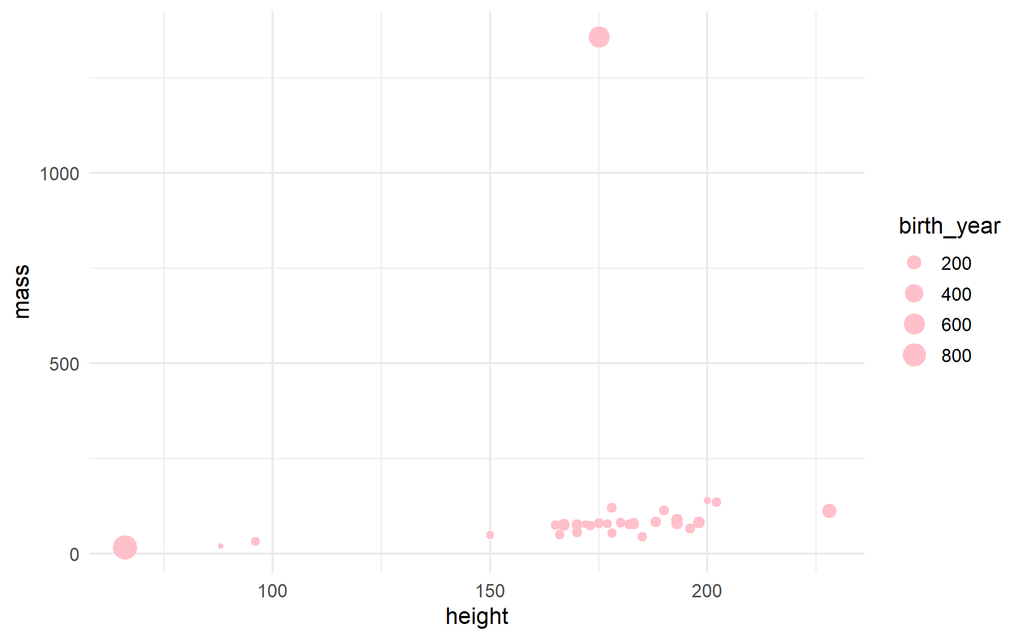

```r
# All three mapped numerical variables must be available for these points.
starwars_complete <- starwars_df %>% drop_na(height, mass, birth_year)

ggplot(starwars_complete,
       aes(x = height, y = mass, size = birth_year)) +
  geom_point(color = "pink")
```

The colour is outside `aes()` because it is the same for every point. The plot uses 36 characters; 51 have a missing value in at least one of these three variables. Filtering them explicitly makes the missing-data rule visible. The original gender colour mapping is redundant when all points have a fixed colour, so I removed it.

## Exercise 3: add the labels

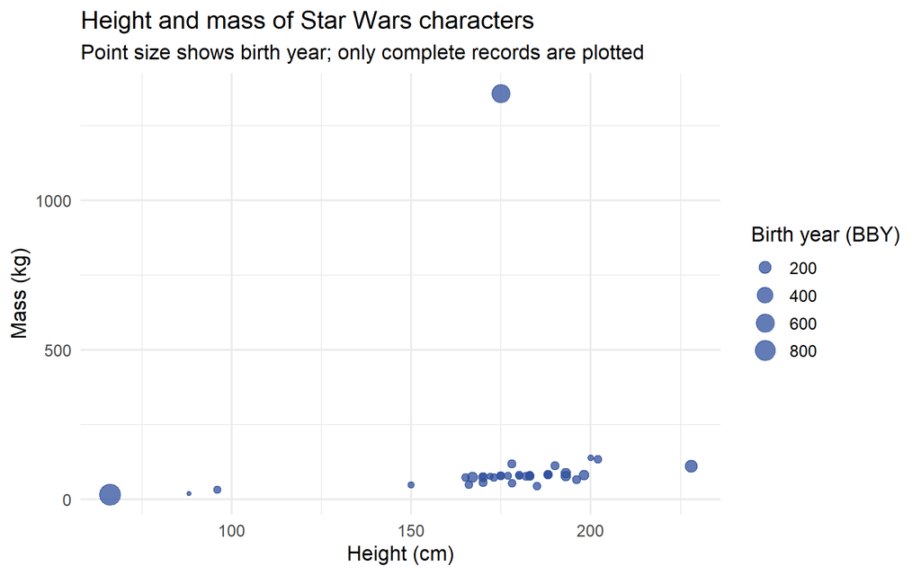

```r
ggplot(starwars_complete,
       aes(x = height, y = mass, size = birth_year)) +
  geom_point(color = "#30509C", alpha = 0.75) +
  labs(
    title = "Height and mass of Star Wars characters",
    subtitle = "Point size shows birth year; only complete records are plotted",
    x = "Height (cm)",
    y = "Mass (kg)",
    size = "Birth year (BBY)"
  )
```

The size legend describes birth year, rather than the physical size of a character. BBY means years before the Battle of Yavin. Jabba’s mass is much larger than the other recorded values, which makes the remaining points look close together on this scale.

## Exercise 4: one numerical variable

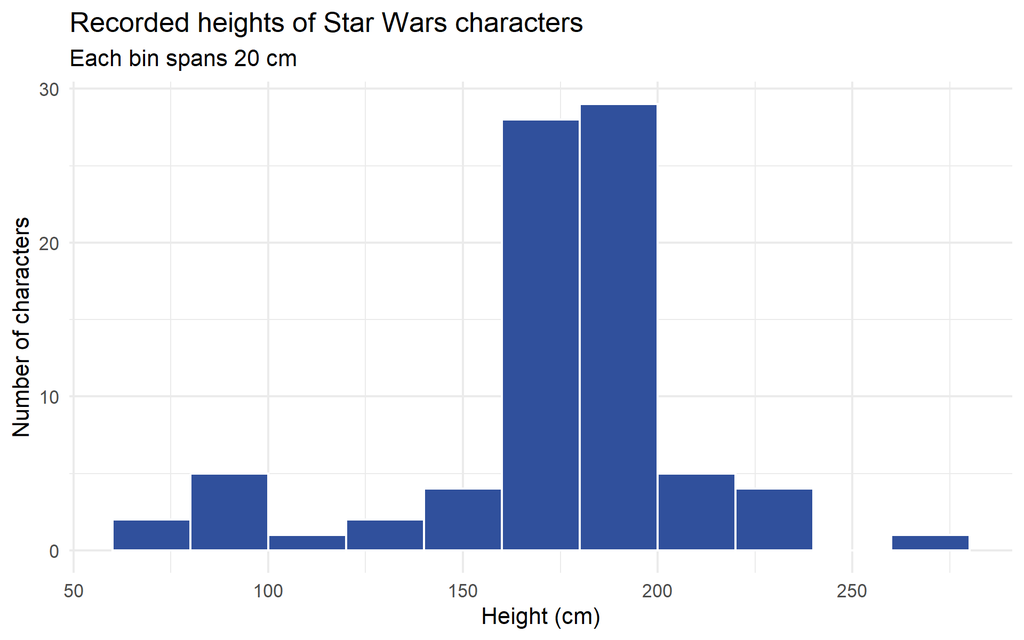

```r
height_data <- starwars_df %>% drop_na(height)

ggplot(height_data, aes(x = height)) +
  geom_histogram(binwidth = 20, boundary = 0,
                 fill = "#30509C", color = "white") +
  labs(title = "Recorded heights of Star Wars characters",
       subtitle = "Each bin spans 20 cm",
       x = "Height (cm)", y = "Number of characters")
```

A binwidth of 20 cm shows the overall shape without making the plot too fragmented. It uses 81 characters and leaves out 6 missing heights. Most heights are around 150–200 cm, with a smaller group of much shorter characters. Recorded heights range from 66 to 264 cm.

## Exercise 5: one numerical and one categorical variable

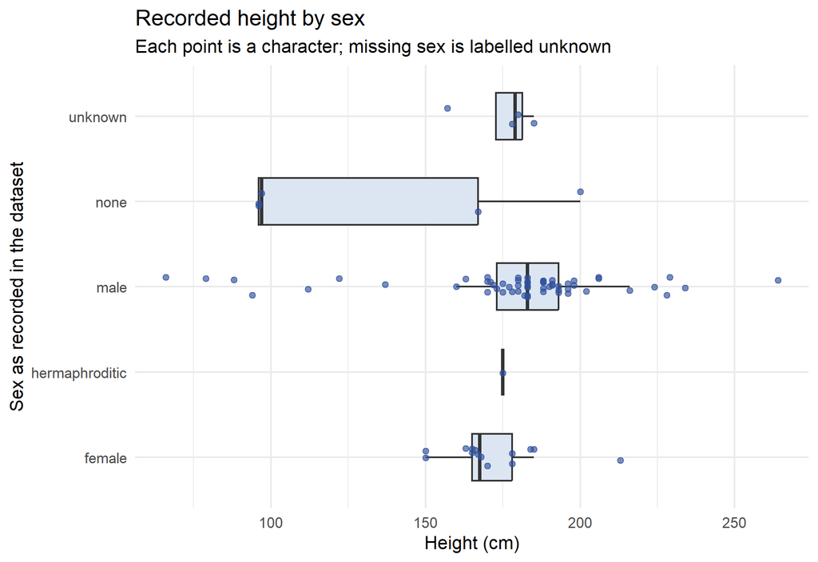

```r
height_by_sex <- starwars_df %>%
  drop_na(height) %>%
  mutate(sex = replace_na(sex, "unknown"))

ggplot(height_by_sex, aes(x = sex, y = height)) +
  geom_boxplot(fill = "#DCE6F3", outlier.shape = NA, width = 0.55) +
  geom_jitter(position = position_jitter(width = 0.12, height = 0, seed = 4),
              alpha = 0.65, color = "#30509C") +
  coord_flip() +
  labs(title = "Recorded height by sex",
       subtitle = "Each point is a character; missing sex is labelled unknown",
       x = "Sex as recorded in the dataset", y = "Height (cm)")
```

```r
height_by_sex %>%
  group_by(sex) %>%
  summarise(characters = n(), median_height_cm = median(height), .groups = "drop")
```

```
## # A tibble: 5 x 3
##   sex            characters median_height_cm
##   <chr>               <int>            <dbl>
## 1 female                 14             168.
## 2 hermaphroditic          1             175
## 3 male                   57             183
## 4 none                    5              97
## 5 unknown                 4             179
```

The median height is 183 cm in the male group and 167.5 cm in the female group, although their heights overlap. Some groups contain very few characters: the hermaphroditic group has only one recorded height. I would not use that single value to describe a wider group. The dots show these differences in group size, which the boxes alone would hide.

## Exercise 6: one categorical variable

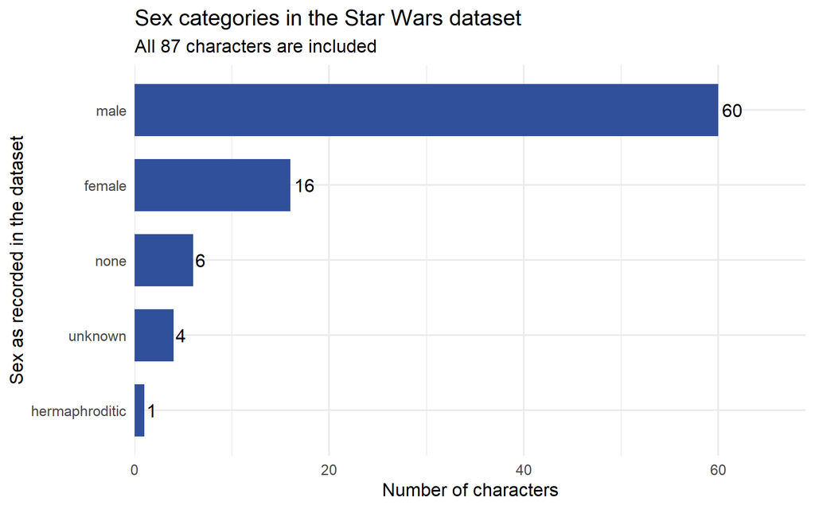

```r
sex_counts <- starwars_df %>%
  mutate(sex = replace_na(sex, "unknown")) %>% count(sex)

ggplot(sex_counts, aes(x = reorder(sex, n), y = n)) +
  geom_col(fill = "#30509C", width = 0.7) +
  geom_text(aes(label = n), hjust = -0.2) +
  coord_flip() +
  scale_y_continuous(expand = expansion(mult = c(0, 0.15))) +
  labs(title = "Sex categories in the Star Wars dataset",
       subtitle = "All 87 characters are included",
       x = "Sex as recorded in the dataset", y = "Number of characters")
```

The male category is the largest, with 60 characters, followed by the female category with 16. Four characters have no recorded sex and are shown as unknown. This describes the characters in this dataset, not a randomly sampled population.

## Exercise 7: two categorical variables

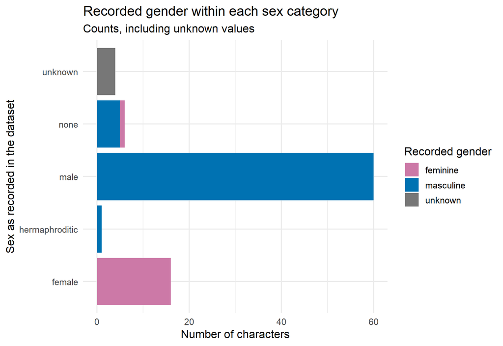

```r
category_data <- starwars_df %>%
  mutate(sex = replace_na(sex, "unknown"),
         gender = replace_na(gender, "unknown"))

ggplot(category_data, aes(x = sex, fill = gender)) +
  geom_bar() +
  coord_flip() +
  scale_fill_manual(values = c(feminine = "#CC79A7",
                               masculine = "#0072B2", unknown = "#777777")) +
  labs(title = "Recorded gender within each sex category",
       subtitle = "Counts, including unknown values",
       x = "Sex as recorded in the dataset", y = "Number of characters",
       fill = "Recorded gender")
```

```r
category_data %>% count(sex, gender)
```

```
## # A tibble: 6 x 3
##   sex            gender        n
##   <chr>          <chr>     <int>
## 1 female         feminine     16
## 2 hermaphroditic masculine     1
## 3 male           masculine    60
## 4 none           feminine      1
## 5 none           masculine     5
## 6 unknown        unknown       4
```

All 60 characters recorded as male have masculine gender, and all 16 recorded as female have feminine gender. The category `none` contains five masculine characters and one feminine character, so the variables are not identical. The four characters with unknown sex also have unknown gender. These are the dataset’s categories; the chart does not establish a general rule about sex and gender.

## Exercise 8: two numerical and two categorical variables

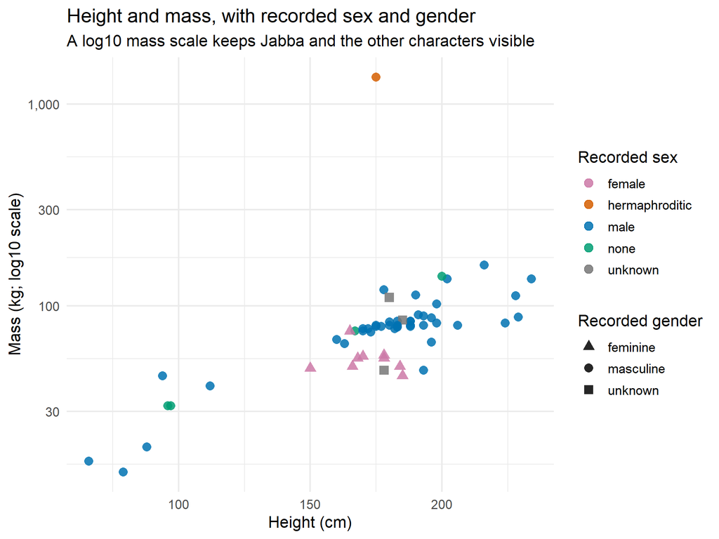

```r
height_mass_data <- category_data %>% drop_na(height, mass)

ggplot(height_mass_data,
       aes(x = height, y = mass, color = sex, shape = gender)) +
  geom_point(size = 3, alpha = 0.85) +
  scale_y_log10(breaks = c(10, 30, 100, 300, 1000),
                labels = scales::label_comma()) +
  scale_color_manual(values = c(
    female = "#CC79A7", hermaphroditic = "#D55E00", male = "#0072B2",
    none = "#009E73", unknown = "#777777")) +
  scale_shape_manual(values = c(feminine = 17, masculine = 16, unknown = 15)) +
  labs(title = "Height and mass, with recorded sex and gender",
       subtitle = "A log10 mass scale keeps Jabba and the other characters visible",
       x = "Height (cm)", y = "Mass (kg; log10 scale)",
       color = "Recorded sex", shape = "Recorded gender")
```

The numerical variables are height and mass. Colour shows sex and shape shows gender. This plot includes 59 characters; 28 have a missing height or mass. Unknown categorical values remain visible.

Taller characters generally appear heavier, but the relationship is far from exact. Jabba has a recorded mass of 1,358 kg at a height of 175 cm and stands well above the other points. I kept this observation and used a log scale rather than removing it. Equal vertical distances therefore represent equal ratios of mass, rather than equal differences in kilograms. The category sizes are uneven and sex and gender overlap strongly, so this plot alone is not a useful test of separate group effects.

## Checks and use of AI

I used ChatGPT to help draft the code and descriptions. The code was run in R, and the counts and summaries above were checked against the dataset. Missing numerical values are handled separately for each plot, rather than removing every character with any missing value.